# 1 Introduction

## 1.1 Background to the Study

Advocates of Microfinance institutions (MFIs) hail the industry for availing financial services to the poor and the financially excluded. Data from 2015, for example, shows that MFIs disbursed $92.4 billion to 116.6 million borrowers and accepted $58.9 billion from 98.4 million depositors (Market 2014). Supporters of Microfinance (MF) further associate it with improved household welfare (Meador and Fritz 2017; You 2013), increased purchasing power and a higher employment rate (Raihan, Osmani, and Khalily 2017; K. Lopatta and Tchikov 2016). Also, MF supporters contend that it leads to improved gender parity (Mafukata, Dhlandhlara, and Kancheya 2017; Zhang and Posso 2017) and enables families to cope with the effects of climate change (Fenton, Paavola, and Tallontire 2017) among other benefits.[^1]

Other researchers, however, have uncovered mixed outcomes from Microfinance (MF) interventions. For example, Ganle, Afriyie, and Segbefia (2015) found that while some women indeed get empowered due to access to credit, most have little control over the subsequent spending. At the same time, a significant proportion suffers harassment from MF agents’ for failing to repay the loans. Van Rooyen, Stewart, and De Wet (2012) also arrive at a similar conclusion.

On the other extreme, some scholars dispute the benefits of MF altogether. For instance, some researchers posit that MF does not boost employment and education among the rural poor (Bauchet and Morduch 2013). Other researchers link micro-credit to increased child labour (Hazarika and Sarangi 2008), raised gender inequalities in access to finance (Zulfiqar 2017), and reduced entrepreneurial spirit among the poor (Field et al. 2013). The apprehension around the high interest rates charged by MFIs and inappropriate lending practices that fail to account for the target clients’ social, cultural, and economic context is also gaining prominence (Chester, Alam, and Haase 2016). Taken together, the case against MF paints a bleak future of MF. Some studies recommend a re-examination of the MF business model and call for better industry regulation (Johnson 2013; Ghosh 2013). Without reforms, conclude Chester, Alam, and Haase (2016), “the MF industry could not only ruin the lives of many borrowers but also ruin itself” (pp. 28).

Despite these contradicting views, MFIs continue to attract interest from governments, state agencies, donor organisations, philanthropists and increasingly commercial capital providers. Initially, MFIs ran on the non-governmental organisation (NGO) model relying chiefly on donors to finance their operations (D’Espallier et al. 2017). The NGO oriented model has emphasised the social mission of MFIs- that is, availing financial services to the poor and the financially excluded (Ashta and Hudon 2012). The model played down the profit motive (Ashta and Hudon 2012).

However, some MFIs have been transforming their institutional structure from NGOs to commercial entities (D’Espallier et al. 2017). This study evaluates the possible impacts of the transformation of MFIs on their financial sustainability and outreach to the financially excluded. The shift happens when an MFI converts from a donor-funded NGO to a regulated financial institution (RFI) that derives its capital primarily from commercial sources. The rationale for the transformation is that it would enable MFIs to access commercial sources of capital and lead to improved financial sustainability, efficiency, and social performance (Louis, Seret, and Baesens 2013).

Other benefits of the transformation include improved customer service, a more extensive range of products, and enhanced control and governance(Srnec, Divivsova, and Svobodova 2008). Consumers and other stakeholders would also reap the benefits of regulating MFIs directly (Meagher et al. 2006) and indirectly (Hartarska and Nadolnyak 2007). Nevertheless, the process of transformation is complicated and dependent on the country-specific regulatory framework. Thus, although most research delineates a point in time when an MFI ceases to be an NGO and becomes a commercial entity, there are essential preparations before the transformation that are often overlooked (D’Espallier et al. 2017).

The transformation of MFIs leads to a change in their capital structure and hence, governance. As research in corporate finance indicates, there is a link between the capital structure of corporations and their financial performance. For example, family-owned businesses with lower leverage exhibit higher profitability (Hamid, Abdullah, and Kamaruzzaman 2015) in line with the pecking order theory of capital structure. Other studies indicate that leverage is positively related to performance (Fosu 2013; Berger and Di Patti 2006), including MFIs (Kar 2012) in line with the agency theory. The effects of capital structure on financial performance may vary across industries, regions, and even depending on the performance metric chosen.

However, MFIs have a double bottom line. Transformed MFIs strive to perform well financially as well as socially. Turning a profit enables MFIs to be sustainable going concerns. On the other hand, social performance is the source of legitimacy for MFIs and the critical reason for receiving donations and subsidies. MFIs should offer financial services to the section of the population neglected by the mainstream financial institutions. The existence of a social mission and financial goals makes it harder to evaluate the effects of capital structure on MFI performance compared to purely commercial firms.

There is an extensive body of research on the effects of the transformation of MFIs. Much of this research has compared the performance of MFIs before and after the conversion. There is a consensus that the conversion of MFIs can affect both the financial and social performance of the transformed MFIs (Chahine and Tannir 2010; Mersland and Strom 2010). However, there is disagreement regarding the direction and magnitude of the effects of transformation (Mersland and Strom 2010; D’Espallier et al. 2017).

Similarly, the few studies that examine the effects of the resultant capital structures of the transformed MFIs on their performance have uncovered mixed results. For instance, Bogan (2012) established that the use of grant capital by MFIs led to decreased sustainability and operational self-sufficiency. Hoque, Chishty, and Halloway (2011) and Kar (2012) reveal a negative relationship between leverage and outreach, whereas Kyereboah-Coleman (2007) finds the opposite using data from Ghana. Accordingly, this study examines the determinants of financing sources by MFIs in Africa.

For MFIs that have transformed, researchers have yet to establish the factors that influence their level of sustainability and outreach. Much of the research examines financial and social performance separately instead of being the two sides of the same coin. Moreover, although a substantial number of MFIs have transformed, some still operate as NGOs. Little research that questions why some MFIs convert while others retain the NGO model. If financial sustainability for MFIs is so desirable, then it is not apparent why some MFIs would stick to an NGO, not-for-profit model that is not sustainable.

In light of the highlighted deficiencies, this study has the broad objective of evaluating the possible impacts of the institutional transformation of Microfinance institutions in Africa. The study utilises a sample dataset comprising 775 MFIs from 40 countries in Africa available. The data is available from the Microfinance Information Exchange (MIX) and the MIX market database of the World Bank.

## 1.2 NGOs to Banks: Rationale for Transforming MFIs

Critics of the NGO based model of MFIs cited its unsustainability and blamed it for crowding out alternative providers of MF services (Kota 2007) while masking internal inefficiencies in MFIs (Caseau and Grolleau 2020). Moreover, donors could not be relied upon to fund MFIs indefinitely. Also, dependence on donor funding left the MFIs exposed to global macroeconomic shocks (D’Espallier et al. 2017), which spread across countries through the financial system (Schnabl 2012). For instance, the global financial crisis led to a decline in development assistance and capital flows to developing countries which, in turn, affected MFI financing (Leach-Kemon et al. 2012; Wagner and Winkler 2013).

Thus, in the absence of alternative sources of finance, MFIs are likely to experience funding shortages in crisis periods (Constantinou and Ashta 2011). Additionally, researchers have uncovered a link between countries’ state of bilateral political relationships and the flow of funds to MFIs (Garmaise and Natividad 2013). Consequently, a diplomatic or trade row could also affect the flow of funding to MFIs, especially in the characteristically vulnerable developing countries. Thus, the NGO model is not only unsustainable but also susceptible to both political and economic dynamics.

This backdrop was a realisation that availing financial services to the poor could be pursued as a profit-based value proposition (Rhyne and Christen 1999). The introduction of the profit element meant that MFIs could carry out their services without relying extensively on donations and subsidies (Duvendack and Maclean 2015). In the long run, the sustainability arising from the transformation of MFIs would enable them to expand access to financial services to the poor and the financially excluded (Brown, Guin, and Kirschenmann 2012; Sarma 2011). However, given that the central focus of MF was on the poor, researchers began to question the compatibility of the pro-poor financial inclusion agenda of MFIs with the profit-oriented school of thought. At the heart of the debate, which continues to date, is that commercialisation of MFIs could result in mission drift[^2] away from serving the poor in pursuit of profits (Im and Sun 2015; Mia and Lee 2017).

Literature is abundant on the question of whether the transformation of MFIs causes mission drift. Some studies assume that the transformation results in mission drift (Mia and Lee 2017; Wagenaar 2012; Kerstin Lopatta et al. 2017; Roberts and Whited 2013). Other scholars find the transformation beneficial or at least not causing mission drift (Im and Sun 2015; Lutzenkirchen, Weistroffer, and Speyer 2012; Quayes 2012; Mersland and Strom 2010). Another strand of related research uncovers both positive and negative results from the transformation(Kar 2012; Caudill, Gropper, and Hartarska 2009). There is also lots of research on the effects of the conversion on social versus financial outcomes and efficiency (Bogan 2012; Kar 2012; Tchuigoua 2014; Khachatryan, Hartarska, and Grigoryan 2017). However, little research has probed the questions raised in this study. The following section is an overview of the transformation of MFIs globally and in Africa.

## 1.3 Overview of the Transformation of MFIs

In 1992, PRODEM, an MFI in Bolivia converted into Bancosol, a commercial bank. This change marked the beginning of the transformation of MFIs to commercial entities. Since then, numerous MFIs have transformed (Table 1.1.). Most of the initial MFIs transformed into commercial banks or finance companies, apart from Card Rural Bank, which changed to a rural bank and Banco ADEMI, which turned into a commercial development bank. This trend has been consistent to this day. Beyond the MFIs highlighted in Table 1.1, other MFIs that have transformed outside Africa include BRAC (Bangladesh) and ACLEDA (Cambodia).

Table 1.1: Sample of Transformed MFIs Globally

| NGO_name | New_name | New_structure | CountryYear |
| --- | --- | --- | --- |
| PRODEM | BANCOSOL | Commercial Bank | Bolivia, 1992 |
| CORPOSOL | FINANSOL | Commercial Finance Company | Colombia, 1993 |
| AMPES | Financiera Calpia | Finance Company | El Salvador, 1995 |
| PRO CREDITO | Caja Los Andes | Finance Company | Bolivia, 1995 |
| CARD | CARD Rural Bank | Rural Bank | The Philippines, 1995 |
| ADEMI | Banco-ADEMI | Commercial Development Bank | Dominican Republic, 1998 |
| ACP | MIBANCO | Commercial Bank | Peru, 1998 |
| K-REP | K-REP Bank | Commercial Bank | Kenya, 1999 |

Source: Campion and White (1999)

In Africa, many MFIs have changed to commercial entities from the year 2000 and beyond. In Uganda, for instance, the Bank of Uganda granted an operating license to Uganda Microfinance Union (UMU) three years after starting off the road to the transformation. Several MFIs have transformed into commercial entities in Kenya, including Faulu (2010) and the Kenya Women Finance Trust (2010). OIBM in Malawi (2002), PRIDE (2009) in Tanzania and OI-SASL (2013) in Ghana has also transformed into commercial entities.

The examination of the transformation of the MF industry should sensibly start with the review of the changing landscape in the national financial sectors. Typical characteristics of financial sectors in most countries include Intense competition, increased innovation, and rapid technological changes. Consequently, the MF services space is no longer the preserve of MFIs. The industry has attracted mainstream commercial banks, MF-oriented commercial banks, credit unions, building societies, and insurance companies. Financial technology (FinTech) firms have also come in (individually or in partnership with mainstream financial institutions) by offering mobile,[^3] internet-based[^4] MF service and peer-to-peer/crowdlending[^5] (Table 1.2). Although some researchers have argued that the digital divide could limit the effectiveness of FinTech based MFIs outfits (Yartey 2017; Griffoli 2017), the prevalence of low-cost smartphones indicates that digital MF could be the future of the industry (Yum, Lee, and Chae 2012). To sum up, the changing MF landscape means that MF providers have to streamline their operations to improve their efficiency and maintain relevance in the market.

Furthermore, although MF was initially targeted at the poorest of the poor, predominantly living in remote rural villages where mainstream banks could not reach, MFIs now target all the financially excluded individuals. Thus, MFIs (and their competitors) offer MF services in urban areas and even operate in developed countries (Kota 2007). This paradigm shift has had several implications. For example, there has been a rise of microfinance-oriented commercial banks that were never MFIs initially. In other cases, some commercial banks have acquired MFIs, and thus incorporated them into the mainstream commercial banking portfolio. In some other instances, there have also been mergers between an MFI and a commercial bank.[^6]

Moreover, there have been mergers between MFIs. In the most extreme cases, MFIs have converted entirely into commercial banks and have been duly regulated under banking laws. This rapidly shifting landscape may also inform the need for MFIs to transform to efficiently compete in a market gaining traction amongst players from mainstream financial industries.

Table 1.2: Sample of Internet and Mobile MF Providers

| MF_Provider | Country | Platform |
| --- | --- | --- |
| KIVA Microfund | Global | The Internet |
| Stonehenge Telkom | Global | The Internet/ Mobile |
| M-Shwari | Kenya | Mobile |
| AYE Microfinance | India | The Internet/ Mobile |
| CUMPLO | Chile | The Internet (Peer to peer) |
| Prosper.com | USA | The Internet (Peer to peer) |
| Popfunding.com | South Korea | The Internet (Peer to peer) |

Source: Authors’ Compilation from the Literature

The transformation of MFIs is not without its challenges. In a particularly extreme case, the conversion of MFIs to for-profit entities was declared unconstitutional in Kosovo (Hasani and vCukalovic 2013).[^7] Also, three additional categories of problems arise in converting MFIs into for-profit legal corporations: the integration into the formal financial system, ownership and governance, and organisational development (Campion and White 1999). The integration of the transformed MFIs into the formal financial system raises several challenges. For example, the political and economic environment determines the timing of successful transformations. Thus, the economic and political climate is an essential factor to consider (Kenya 2012).

Transformation also implies setting up a board that oversees the running of the organisation. The board typically sets the mission and vision of the organisation as well as its investment strategy. Thus, an ineffective board could hinder the implementation of transformation (Campion and White 1999) and even the performance of an MFI post-transformation. Lastly, issues such as the organisational culture and human resource development are critical to a successful transition. For most MFIs that have moved from the NGO model, the management has to alter the organisation’s culture to cater to a commercial, and thus, a more customer-centric orientation (Christen 2001). These adjustments have resulted in substantial costs of training and mentorship.

## 1.4 Motivation for the study

Different schools of thought hold differing views regarding the potential consequences of the transformation of MFIs. The sustainability perspective[^8] considers the transformation as desirable for MFIs to attain financial self-sufficiency. On the other hand, the welfare standpoint sees the transformation as conflicting with the social mission of MFIs. The win-win approach attempts to reconcile both the welfare and the sustainability perspectives by bringing together the potential benefits from both schools of thought (Kodongo and Kendi 2013). The debate between the three schools of thought has dominated the research on the institutional transformation in MFIs.

A broad range of research has documented the institutional change in the MF industry (prominent first examples include,Joann Ledgerwood (1998) and Joanna Ledgerwood and White (2006)). The subsequent studies examined the effects of the change on the trade-off between financial sustainability and social performance. A remarkable pioneering example of research in this area is that of Frank, Lynch, and Schneider-Moretto (2008), who found that transformation led to a higher client outreach, higher growth in the loan portfolio, and higher product diversification. More importantly, they established that conversion allowed more women customers to access services, although the overall percentage of women receiving the services declined. Subsequent studies support their view, for example, (Hartarska and Mersland 2012; Bos and Millone 2015 ; D’Espallier et al. 2017).

A substantial extension of studies on the transformation of MFIs has examined the financing structures in the transformed MFIs. There are mixed outcomes from the research. For instance, (Bogan 2012) examined the relationship between capital structure and MFI efficiency and sustainability. The study uncovers a link between capital structure, MFI size, and financial performance. Specifically, there is a negative relationship between the use of grants and financial performance. These results are close to the outcomes of the research by (Hudon and Traca 2011). They also found a positive relationship between grant financing and financial performance, which turns negative beyond a certain threshold, in line with D’Espallier et al. (2017).

A related study by Kar (2012) found no relationship between debt financing and breadth of outreach and women participation as loan clients and recommended research along this line about equity financing. Subsequent analysis has not resolved this stalemate (Hoque, Chishty, and Halloway 2011; Kyereboah-Coleman 2007; Khachatryan, Hartarska, and Grigoryan 2017; D’Espallier et al. 2017). The mixed outcomes from previous studies motivate the focus on the effects of capital structure on the performance of MFIs in this research.

Much of the existing strand of research on MFI transformation stems from the perceived possibility of mission drift by MFIs that have undergone the change from the NGO based model to the commercial model. The primary manifestation of the transformation has been the domination of debt, deposits, and equity in the capital structure of the transformed MFIs (The Microfinance Information Exchange, 2017). Figure 1.1 shows the funding structure of 1330 MFIs globally that avail their data to the MIX pooled database. The regional disparity in the financing structure is particularly striking. In Latin America and the Caribbean (LAC), Eastern Europe and Central Asia (ECA), East Asia and the Pacific (EAP), and Africa, MFI source their capital mainly from deposits. In contrast, MFIs in South Asia get most of the capital from borrowings. In North Africa and the Middle East, debt and equity are equally likely to be a source of funding for MFIs.

Except for the MENA region, equity consistently consists of less than 25% of the funding of MFIs, with the figure being lowest in Africa (18%), LAC (18%), and ECA (16%). Debt is a chief funding source compared to equity, with four of the six regions having debt accounting for more than 25% of the total funding. The exception is Africa and LAC, where borrowings account for 11% and 18% of the total financing. Notable also is the tiny proportion of deposits to total capital observed in the MENA region. The regional disparity in financing patterns for MFIs provokes several questions. Why is there such a regional disparity in capital structures among MFIs?

Moreover, in the African setting, do such regional disparities exist? If the disparities exist, then what explains the differences? This study also seeks the determinants of the observed financing structures among transformed MFIs to inform policy-making for the MF sector and target the entire capital market. This study addresses this open issue from the capital structure perspective regarding the financing of hybrid organisations.

The examination of the drivers of the financing structure of MFIs is necessary because the transformation of MFIs implies that both the proportion and the importance of donor funding would be declining in most MFIs. The increasing importance of commercial financing from the commercial interest perspective should be the foundation from which researchers examine whether or not transformed MFIs are achieving financial sustainability and social mission. It is only when such research establishes how the business orientation affects the social mission of MFIs that the need for corrective action gets flagged timeously.

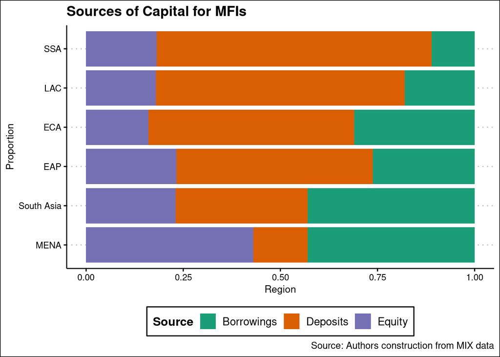

Figure 1.1: Funding structure of MFIs Across the Globe by Region (2015)

Although the transformation of NGOs has its merits, most MFIs have still not transformed(D’Espallier et al. 2017). Therefore, the key outputs of this study are the motives behind some MFIs transforming while other MFIs retain the NGO model. The current literature has been overly concerned with the transformed MFIs and has not addressed this issue. Even among the transformed MFIs, researchers have not uncovered the drivers of the decision by MFIs to change and the necessary preconditions for transformation. The existing research takes for granted that MFIs transform to be sustainable. Given the benefits of transformation touted in the numerous studies, then most MFIs should have already converted.

Moreover, as Morduch and Ogden (2019) argues, if there is no trade-off between financial performance and social performance of transformed MFIs, NGOs would not exist. However, this is not the case. Therefore, it appears that some additional factors influence the decision by MFI to either transform or retain the NGO model. As noted, there is no conclusive evidence on the effects of MFI transformation on their performance. These contradicting results could be because of numerous unknown reasons. It is in order, therefore, to establish the factors that influence the sustainability and outreach of transformed MFIs. Similarly, establishing the factors that moderate the relationship between capital structure on the one hand and the financial performance and social performance of MFIs in Africa is a novel contribution to the research.

Recent literature also suggests that the performance of MFIs is dependent on the broader macroeconomic conditions as well Ahlin, Lin, and Maio (2011), and is country-specific (D’Espallier et al. 2017). Thus, in the analysis of the institutional transformation of MFIs, cross-country and regional differences must be factored in. However, most studies have not considered the cross country and regional variations. Failure to consider regional disparities means that the extant research fails to capture local contextual peculiarities.

These regional differences motivate the choice of MFIs in Africa as the unit of analysis. By focusing on Africa, the study isolates the regional and country heterogeneity of the effects of transformation. This issue could have affected the results of research based on pooled global datasets. Thus, the output of the study are unique to Africa and therefore more actionable. To sum up this section, the study significantly extends the existing literature on MFI transformation. The following section outlines the purpose statement.

## 1.5 Purpose Statement

This research evaluates the transformation of MFIs in Africa and how this transformation impacts the financial and social performance of MFIs and financial inclusion on the continent.

## 1.6 Research Questions

The study specifically seeks answers to the following research questions.

1. Why do some MFIs in Africa transform into the commercial model while others retain the NGO Model?
2. To what extent has the institutional transformation of MFIs in Africa affected financial inclusion?
3. After transformation, what factors explain the joint level of sustainability and outreach by MFIs in Africa?
4. What are the drivers of financial efficiency, social efficiency and socio-financial efficiency of MFIs in Africa?
5. What are the factors that influence the choice of financing sources by transformed MFIs in Africa?

## 1.7 Significance of the Study

In pursuing the stated objectives, this study fills a theoretical deficiency in the capital structure of quasi-commercial organisations that have a social dimension of value. The context of shareholder and debt holder importance was the foundation of capital structure and agency theories. Arguments from this genesis have not factored in corporations with extra dimensions of value, such as achieving social goals. As a case in point, `Modigliani and Miller` capital structure theory may not be entirely applicable to MFIs where value also has a social facet. In the Modigliani and Miller capital structure theory, the value of a firm is the sum of equity and debt components in the capital structure of a corporation. The value of a company is an increasing function of the debt proportion of capital structure up to the point where the costs of financial distress outweigh the benefits of the interest tax shield. The empirical output has implications on policy direction relating to MFIs in Africa.

The study also has a variety of policy implications. These policy implications are related to the research objectives. For instance, what are the factors that drive MFIs to transform or fail to transform? The answer to this question would inform the crafting of supportive policies if transformation is indeed desirable. Similarly, uncovering the drivers of financial inclusion, outreach, and sustainability of MFIs after the conversion would inform policy-making supporting financial inclusion. Establishing the determinants of financing sources would allow policy-making to ease fundraising by MFIs. If the drive for institutional transformation is to achieve the desired effects, then the change in the MFI funding structures must not compromise social objectives. If the conversion of MFIs negatively affects social performance, there would be no way to justify the transformation of MFIs. The change of MFIs should improve their sustainability, but not to the detriment of social performance.

Also, if the transition results in a decline in social performance, then the transformation could be treated as the transition point of transformed MFIs into the mainstream banking system (Kent and Dacin 2013). Therefore, it is crucial to investigate the outcomes of the change to inform the design of a framework that would not expose the poor and financially excluded to the same level of exclusion by the financial system that MFIs ought to address. Doing this would be equivalent to allowing MFIs to use the underprivileged as a ladder to climb into the mainstream system and abandoning them shortly after, which raises ethical questions. Similarly, identifying factors that influence the choice of financing structures has implications for the design of policies aimed at the capital market. For the same reasons, identifying factors that influence the social performance of transformed MFIs is also helpful, not just for policy design but also for managerial decision making.

Finally, the efficiency of MFIs is a significant determinant of both the financial and social performance of MFIs. According to the efficiency theory, the positive relationship between concentration and profitability is indicative of the tendency of firms that are efficient to be successful and hence dominant in their industries (Lipczynski, Wilson, and Goddard 2005). Efficiency gains could result from economies of scale and cost-saving schemes initiated by the management. Enhanced efficiency by MFIs is, therefore, desirable. However, the efficiency of MFIs should encompass both financial and social dimensions. The entry of commercial sources of capital may affect both the financial and social efficiency of MFIs in line with agency theory. Therefore, it is vital to establish the relationship between capital structure and efficiency to inform both the management and stakeholders of the dynamics in the MFI sector regarding effectiveness in the new era of commercial funding.

## 1.8 Key Findings of the Research

The research examined the transformation of MFIs in Africa. In this section, I summarize the findings for each of the research questions.

1. *Why do some MFIs in Africa transform into the commercial model while others retain the NGO Model?*

In addressing this research question, I applied logit, probit and multinomial logit models to evaluate the factors that drive NGO-type MFIs to convert to commercial profit-oriented MFIs. The results show that at the firm level, age and size influence transformation. Legal tradition, institutional quality, and stock market development are significant factors at the country level. Specifically, larger and older MFIs are less likely to be NGOs. These results suggest that as MFIs mature, they tend to convert to the commercial model either due to pressure from donors or the decision by management to pursue the double bottom line as they get more financially sustainable and as donor support subsides. MFIs in civil law countries are also less likely to be NGOs, while those in countries that follow other legal traditions are more likely to adopt the commercial model. Again, Institutional quality raises the chances of MFI conversion to the commercial model. Institutional quality captures a wide range of governance measures that enhance contract enforcement and property rights. Hence, countries with stronger institutions tend to attract more private investments and hence the higher rate at which MFIs adopt the commercial model. Stock market capitalisation and private credit to GDP have a negative relationship with transformation. The development of capital markets corresponds to better access to financial services, a pre-condition for financial inclusion. Hence, MFIs in countries with well-developed financial markets will likely be competing against established financial intermediaries for the existing market. The competition limits the financial viability of MFIs. Hence, MFIs in these markets will likely remain NGOs that serve small population in the fringes of the market.

2. *To what extent has the institutional transformation of MFIs in Africa affected financial inclusion?*

In this analysis, I used the fixed effects and random effects models to examine how the transformation of microfinance institutions to the profit-oriented model has affected financial inclusion in Africa. I used three indicators of financial inclusion. To the proxy depth of MFI outreach, I used the per cent of female borrowers and average loan balance per borrower. Gross loans to total assets proxied the breadth of outreach. The primary independent variable was the legal form of MFIs: NGOs, NBFIs, commercial banks, cooperatives and rural banks. The control variables were age, region, operating expense to assets ratio, donations to assets ratio, capital to assets ratio, asset structure, MFI size (logarithm of assets), education and profit margin. Our results show that the change from the NGO model to the commercial models could negatively affect the depth of financial outreach, especially given that NGOs characteristically have better outreach to women and advance smaller denomination loans on average than for-profit MFIs. Also, NGOs have higher median gross loans to assets ratio than other legal forms of MFIs except for credit unions/cooperatives. Overall, the results indicate the potential mission drift, where MFIs that convert to the for-profit model focus more on financial sustainability to the detriment of outreach to the unbanked.

3. *What are the drivers of financial efficiency, social efficiency and socio-financial efficiency of MFIs in Africa?*

In this objective, I examined the drivers and levels of financial efficiency, social efficiency, and socio-financial efficiency of microfinance institutions (MFIs) in Africa for 2000-2019. I estimated MFI financial efficiency, social efficiency, and joint financial and social efficiency (socio-efficiency) of MFIs in Africa using the output-oriented Data Envelopment Analysis (DEA). The inputs to the DEA model were equity and liabilities and operating expenses to assets ratio. The social performance outputs in the DEA model were the per cent of female borrowers and the average loan balance per borrower, noting that a lower average loan balance corresponds to deeper outreach. Operational self-sufficiency, a ratio of revenue to operating expenses, was the corresponding financial output measure. I then bootstrapped the efficiency scores. These scores were the dependent variables in the subsequent fixed and random effects regressions. Broadly, our results show a trend of declining financial efficiency by MFIs but no discernible trend in social and socio-financial efficiency. However, NGOs have markedly better social efficiency and socio-financial efficiency scores than other legal forms of MFIs. Surprisingly, only cooperatives and rural banks consistently outperform NGOs financially. The proxies for financial sector development, stock market capitalization to GDP and private credit to GDP, have a negative relationship with social and socio-financial efficiency. Financial efficiency has an inverse relationship with both the size and asset structure of MFIs. These results suggest that the commercialization of MFIs does not necessarily improve their financial sustainability.

4. *After transformation, what factors explain the joint level of sustainability and outreach by MFIs in Africa?*

Drawing from the classification matrix by Chattopadhyay and Mitra (2017) I examined the extent to which MFIs in Africa meet their dual objectives and the factors that drive the attainment of financial and social goals. I captured social goals using the per cent of female borrowers, while the operational self-sufficiency (OSS) captured financial performance. The code zero captured MFIs with a proportion of female borrowers greater or equal to 0.5, and an OSS of at least one. MFIs that did not meet any of these thresholds took a code of one. The other two categories (2 and 3) captured MFIs that achieved one goal and failed in the other. I applied a multinomial logit model. The results show that most MFIs in Africa attain the dual objectives, at 35.88% compared to 14.76% that fail in both missions. 23.85% fail socially but succeed financially, and 25.55% succeed socially while failing financially. In total, 61.43% of MFIs attain their social goals. 40.31% fail financially. However, these results vary across the legal status of an MFI. Rural banks and NGOs are more likely to achieve the dual goals than banks, NBFIs and credit unions. Accordingly, the legal status of an MFI is the most significant driver of the extent of the achievement of the dual goals. NGOs have the highest likelihood of achieving both financial and social goals. This result highlights the risk of mission drift should MFIs convert to the for-profit model. Larger MFIs have a higher chance of meeting financial and social goals. Likewise, larger firms are more likely to succeed socially while failing financially, meaning that larger firms emphasise social impact. Age raises the probability that an MFI will fail financially and socially, as does stock market capitalisation to GDP that proxies capital markets development. Lastly, MFIs in countries following civil law and other legal traditions are more likely to meet at least one of the objectives, unlike MFIs in common law countries.

5. *What are the factors that influence the choice of financing sources by transformed MFIs in Africa?*

This research item examined the sources of finance for MFIs in Africa and their associated drivers. The indicators of financing sources were debt-equity ratio (leverage) and capital to assets ratio (equity), deposits to assets ratio (deposits), and donations to assets ratio (donations). We used fixed and random effects models with each of the financing sources as the dependent variables. The significant determinants of financing at the firm level are size, age, legal status, and profitability consistent with theory. For example, asset structure varies inversely with leverage. At the country level, institutional quality (KKM) varies inversely with deposits and donations. Interestingly, coefficients of financial development are not significant across all financial structure proxies, going against stylised facts on the macro-level drivers of firms’ financing structure. The results suggest that firm-level factors are more relevant in determining the financing structure of MFIs.

## 1.9 Outline of the Study

The remainder of the work is organised into five standalone chapters of coherent, identifiable aspects of the economics of microfinance in the African context. The proceeding paragraphs highlights each of the chapters.

**Chapter Two**: This chapter explores the factors behind the transformation of MFIs in Africa from NGOs to commercial, profit-seeking entities that rely more on commercial rather than donor funding. Much of the extant research has looked into the potential effects of the transformation. However, few seek the answer as to why MFIs choose or abstain from converting in the first place. The answer to this question would benefit policy makers in dealing with sustainable financial inclusion in Africa and beyond. The analysis rests on the institutional theory of the causes of change in organizations (Scott et al. 2005; Powell and DiMaggio 2012), noting that MFIs have been under increasing pressure to be financially sustainable (D’Espallier, Hudon, and Szafarz 2013).

**In chapter three**: In this chapter, I examine the way the transformation of MFIs from NGOs to commercial, profit-seeking enterprises has affected financial inclusion in Africa using the fixed and random-effects models. The study draws from the agency and capital structure theories given that transformed MFIs rely less on donations and subsidies and more on capital markets for funding. Commercial funders could push managers to emphasize financial performance at the expense of social goals (Sarma 2011). Considering this, the essay examines how the shift has affected lending to women, average loan sizes and gross loans. The study fills a gap in the literature given that much of the existing literature examines the effects of transformation using global datasets, which could mask regional heterogeneity as D’Espallier et al. (2017) suggests.

**Chapter four**: Chapter four assesses levels of financial efficiency, social efficiency, and joint social and financial efficiency (socio-financial efficiency) of MFIs in Africa. The chapter also evaluates the factors that drive these efficiencies. The analysis is in light of the transformation of MFIs from NGOs to commercial entities where agency conflicts could make MFIs less inclined to avail financial services to the financially excluded in favour of profits (Serrano-Cinca and Gutierrez-Nieto 2014). I apply the data envelopment analysis (DEA) approach to quantify the extent that MFIs in Africa translate their assets into financial and social outcomes, which is a novel contribution to financial inclusion in Africa.

**Chapter five**: Chapter 5 examines the factors that drive the simultaneous achievement of financial and social goals by MFIs in Africa. In this section, I use the multinomial logit model to examine the extent to which MFIs simultaneously achieve both their financial and social goals. I construct the dependent variable using the matrix developed by Chattopadhyay and Mitra (2017) as described in section 1.8 above. The output from this section complement those in chapter 4 but using a different methodology for robustness.

**Chapter six**: Chapter 6 examines the funding sources by MFIs in Africa, including the factors determining the sources of financing. The mainstream capital structure theory does not address hybrid organisations with a dual mission, such as MFIs. The results would be useful at informing decisions about financing alternatives for MFIs that would best suit their hybrid nature, more so to meet their social goals while remaining financially sustainable.

**Conclusion**: Finally, the study concludes by summarising findings, offering policy recommendations, and pointing out possible directions for future research.

Ahlin, Christian, Jocelyn Lin, and Michael Maio. 2011. “Where Does Microfinance Flourish? Microfinance Institution Performance in Macroeconomic Context.” *Journal of Development Economics* 95 (2): 105–20.

Ashta, Arvind, and Marek Hudon. 2012. “The Compartamos Microfinance IPO: Mission Conflicts in Hybrid Institutions with Diverse Shareholding.” *Strategic Change* 21 (7-8): 331–41.

Bauchet, Jonathan, and Jonathan Morduch. 2013. “Is Micro Too Small? Microcredit Vs. SME Finance.” *World Development* 43: 288–97.

Berger, Allen N, and Emilia Bonaccorsi Di Patti. 2006. “Capital Structure and Firm Performance: A New Approach to Testing Agency Theory and an Application to the Banking Industry.” *Journal of Banking & Finance* 30 (4): 1065–1102.

Bogan, Vicki L. 2012. “Capital Structure and Sustainability: An Empirical Study of Microfinance Institutions.” *Review of Economics and Statistics* 94 (4): 1045–58.

Bos, Jaap WB, and Matteo Millone. 2015. “Practice What You Preach: Microfinance Business Models and Operational Efficiency.” *World Development* 70: 28–42.

Brown, Martin, Benjamin Guin, and Karolin Kirschenmann. 2012. “Microfinance Commercialization and Mission Drift.” *Die Unternehmung* 66 (4): 340–57.

Campion, Anita, and Victoria White. 1999. *Institutional Metamorphosis: Transformation of Microfinance NGOs into Regulated Financial Institutions*. New York: MicroFinance Network.

Caseau, Cornelia, and Gilles Grolleau. 2020. “Impact Investing: Killing Two Birds with One Stone?” *Financial Analysts Journal* 76 (4): 40–52.

Caudill, Steven B, Daniel M Gropper, and Valentina Hartarska. 2009. “Which Microfinance Institutions Are Becoming More Cost Effective with Time? Evidence from a Mixture Model.” *Journal of Money, Credit and Banking* 41 (4): 651–72.

Chahine, Salim, and L Tannir. 2010. “On the Social and Financial Effects of the Transformation of Microfinance NGOs.” *Voluntas: International Journal of Voluntary and Nonprofit Organizations* 21 (3): 440–61.

Chattopadhyay, Manojit, and Subrata Kumar Mitra. 2017. “Applicability and Effectiveness of Classifications Models for Achieving the Twin Objectives of Growth and Outreach of Microfinance Institutions.” *Computational and Mathematical Organization Theory* 23 (4): 451–74.

Chester, Winston C, Bhuiyan Monwar Alam, and Dwight Haase. 2016. “‘One Slowly Loses Everything’: Development and Debt in San Antonio Aguas Calientes.” *World Development Perspectives* 4: 24–29.

Christen, Robert Peck. 2001. “Commercialization and Mission Drift.” *Occasional Paper* 5.

Constantinou, Dinos, and Arvind Ashta. 2011. “Financial Crisis: Lessons from Microfinance.” *Strategic Change: Briefings in Entrepreneurial Finance* 20 (5/6): 187–203.

D’Espallier, Bert, Jann Goedecke, Marek Hudon, and Roy Mersland. 2017. “From NGOs to Banks: Does Institutional Transformation Alter the Business Model of Microfinance Institutions?” *World Development* 89: 19–33.

D’Espallier, Bert, Marek Hudon, and Ariane Szafarz. 2013. “Unsubsidized Microfinance Institutions.” *Economics Letters* 120 (2): 174–76.

Duvendack, Maren, and Kate Maclean. 2015. “(Mis) Use of Evidence in Microfinance Programming in the Global South: A Critique.” *Contemporary Social Science* 10 (2): 202–11.

Fenton, Adrian, Jouni Paavola, and Anne Tallontire. 2017. “The Role of Microfinance in Household Livelihood Adaptation in Satkhira District, Southwest Bangladesh.” *World Development* 92: 192–202.

Field, Erica, Rohini Pande, John Papp, and Natalia Rigol. 2013. “Does the Classic Microfinance Model Discourage Entrepreneurship Among the Poor? Experimental Evidence from India.” *American Economic Review* 103 (6): 2196–226.

Fosu, Samuel. 2013. “Capital Structure, Product Market Competition and Firm Performance: Evidence from South Africa.” *The Quarterly Review of Economics and Finance* 53 (2): 140–51.

Frank, Christina, Elizabeth Lynch, and Louise Schneider-Moretto. 2008. “Stemming the Tide of Mission Drift: Microfinance Transformations and the Double Bottom Line.” *Women’s World Banking Focus Note* 4 (1): 1–24.

Ganle, John Kuumuori, Kwadwo Afriyie, and Alexander Yao Segbefia. 2015. “Microcredit: Empowerment and Disempowerment of Rural Women in Ghana.” *World Development* 66: 335–45.

Garmaise, Mark J, and Gabriel Natividad. 2013. “Cheap Credit, Lending Operations, and International Politics: The Case of Global Microfinance.” *The Journal of Finance* 68 (4): 1551–76.

Ghosh, Jayati. 2013. “Microfinance and the Challenge of Financial Inclusion for Development.” *Cambridge Journal of Economics* 37 (6): 1203–19.

Griffoli, T. M. 2017. “Banking on Change.” *Finance and Development* 54 (1): 26–29.

Hamid, Masdiah Abdul, Azizah Abdullah, and Nur Atiqah Kamaruzzaman. 2015. “Capital Structure and Profitability in Family and Non-Family Firms: Malaysian Evidence.” *Procedia Economics and Finance* 31: 44–55.

Hartarska, Valentina, and Roy Mersland. 2012. “Which Governance Mechanisms Promote Efficiency in Reaching Poor Clients? Evidence from Rated Microfinance Institutions.” *European Financial Management* 18 (2): 218–39.

Hartarska, Valentina, and Denis Nadolnyak. 2007. “Do Regulated Microfinance Institutions Achieve Better Sustainability and Outreach? Cross-Country Evidence.” *Applied Economics* 39 (10): 1207–22.

Hasani, Enver, and Ivan vCukalovic. 2013. “USTAV REPUBLIKE KOSOVA.”

Hazarika, Gautam, and Sudipta Sarangi. 2008. “Household Access to Microcredit and Child Work in Rural Malawi.” *World Development* 36 (5): 843–59.

Hoque, Monzurul, Muhammad Chishty, and Rashid Halloway. 2011. “Commercialization and Changes in Capital Structure in Microfinance Institutions: An Innovation or Wrong Turn?” *Managerial Finance*.

Hudon, Marek, and Daniel Traca. 2011. “On the Efficiency Effects of Subsidies in Microfinance: An Empirical Inquiry.” *World Development* 39 (6): 966–73.

Im, Junyon, and Sunny Li Sun. 2015. “Profits and Outreach to the Poor: The Institutional Logics of Microfinance Institutions.” *Asia Pacific Journal of Management* 32 (1): 95–117.

Johnson, Susan. 2013. “From Microfinance to Inclusive Financial Markets: The Challenge of Social Regulation.” *Oxford Development Studies* 41 (sup1): S35–52.

Kar, Ashim Kumar. 2012. “Does Capital and Financing Structure Have Any Relevance to the Performance of Microfinance Institutions?” *International Review of Applied Economics* 26 (3): 329–48.

Kent, Derin, and M Tina Dacin. 2013. “Bankers at the Gate: Microfinance and the High Cost of Borrowed Logics.” *Journal of Business Venturing* 28 (6): 759–73.

Kenya, Financial Sector Deepening. 2012. “Transforming Microfinance in Kenya: The Experience of Faulu Kenya and Kenya Women Finance Trust.” *The Journal of FSD Kenya*.

Khachatryan, Knar, Valentina Hartarska, and Aleksandr Grigoryan. 2017. “Performance and Capital Structure of Microfinance Institutions in Eastern Europe and Central Asia.” *Eastern European Economics* 55 (5): 395–419.

Kodongo, Odongo, and Lilian G Kendi. 2013. “Individual Lending Versus Group Lending: An Evaluation with Kenya’s Microfinance Data.” *Review of Development Finance* 3 (2): 99–108.

Kota, Ina. 2007. “Microfinance: Banking for the Poor.” *Finance and Development* 44 (2): 44.

Kyereboah-Coleman, Anthony. 2007. “The Determinants of Capital Structure of Microfinance Institutions in Ghana.” *South African Journal of Economic and Management Sciences* 10 (2): 270–79.

Leach-Kemon, Katherine, David P Chou, Matthew T Schneider, Annette Tardif, Joseph L Dieleman, Benjamin PC Brooks, Michael Hanlon, and Christopher JL Murray. 2012. “The Global Financial Crisis Has Led to a Slowdown in Growth of Funding to Improve Health in Many Developing Countries.” *Health Affairs* 31 (1): 228–35.

Ledgerwood, Joann. 1998. *Microfinance Handbook: An Institutional and Financial Perspective*. The World Bank.

Ledgerwood, Joanna, and Victoria White. 2006. *Transforming Microfinance Institutions: Providing Full Financial Services to the Poor*. The World Bank.

Lipczynski, John, John OS Wilson, and John A Goddard. 2005. *Industrial Organization: Competition, Strategy, Policy*. Pearson Education.

Lopatta, Kerstin, Magdalena Tchikov, Reemda Jaeschke, and Sumit Lodhia. 2017. “Sustainable Development and Microfinance: The Effect of Outreach and Profitability on Microfinance Institutions’ Development Mission.” *Sustainable Development* 25 (5): 386–99.

Lopatta, K, and M Tchikov. 2016. “Do Microfinance Institutions Fulfil Their Promise? Evidence from Cross-Country Data.” *Applied Economics* 48 (18): 1655–77.

Louis, Philippe, Alex Seret, and Bart Baesens. 2013. “Financial Efficiency and Social Impact of Microfinance Institutions Using Self-Organizing Maps.” *World Development* 46: 197–210.

Lutzenkirchen, Cedric, Christian Weistroffer, and B Speyer. 2012. “Microfinance in Evolution: An Industry Between Crisis and Advancement.” *Deutsche Bank Research* 13.

Mafukata, Mavhungu, Willie Dhlandhlara, and Grace Kancheya. 2017. “Reciprocal Relationship of Social Capital and Microfinance Activities in Nyanga, Zimbabwe.” *Development in Practice* 27 (1): 77–89.

Market, MIX. 2014. “Global Outreach & Financial. Performance Benchmark Report-2014.” The Microfinance Information Exchange. Retrieved from http://www. themix. org/mixmarket/publications/2014-global~….

Meador, John, and Andrew Fritz. 2017. “Food Security in Rural Uganda: Assessing Latent Effects of Microfinance on Pre-Participation.” *Development in Practice* 27 (3): 340–53.

Meagher, Patrick, Pilar Campos, Robert Peck Christen, Kate Druschel, Joselito Gallardo, and Sumantoro Martowijoyo. 2006. “Microfinance Regulation in Seven Countries: A Comparative Study.” *Sa-Dhan. New Delhi*.

Mersland, Roy, and R Oystein Strom. 2010. “Microfinance Mission Drift?” *World Development* 38 (1): 28–36.

Mia, Md Aslam, and Hwok-Aun Lee. 2017. “Mission Drift and Ethical Crisis in Microfinance Institutions: What Matters?” *Journal of Cleaner Production* 164: 102–14.

Morduch, Jonathan, and Timothy Ogden. 2019. “The Challenges of Social Investment Through the Lens of Microfinance.” In *A Research Agenda for Financial Inclusion and Microfinance*. Edward Elgar Publishing.

Powell, Walter W, and Paul J DiMaggio. 2012. *Introduction*. Edited by Walter W Powell and Paul J DiMaggio. Chicago: University of Chicago press.

Quayes, Shakil. 2012. “Depth of Outreach and Financial Sustainability of Microfinance Institutions.” *Applied Economics* 44 (26): 3421–33.

Raihan, Selim, SR Osmani, and MA Baqui Khalily. 2017. “The Macro Impact of Microfinance in Bangladesh: A CGE Analysis.” *Economic Modelling* 62: 1–15.

Rhyne, Elisabeth, and Robert Christen. 1999. *Microfinance Enters the Marketplace*. Citeseer.

Roberts, Michael R, and Toni M Whited. 2013. “Endogeneity in Empirical Corporate Finance1.” In *Handbook of the Economics of Finance*, 2:493–572. Elsevier.

Sarma, Sushanta. 2011. “NGO Transformation: Institutional Entrepreneurship in Indian Microfinance.” *Business Strategy Series*.

Schnabl, Philipp. 2012. “The International Transmission of Bank Liquidity Shocks: Evidence from an Emerging Market.” *The Journal of Finance* 67 (3): 897–932.

Scott, W Richard et al. 2005. “Institutional Theory: Contributing to a Theoretical Research Program.” *Great Minds in Management: The Process of Theory Development* 37 (2): 460–84.

Serrano-Cinca, Carlos, and Begona Gutierrez-Nieto. 2014. “Microfinance, the Long Tail and Mission Drift.” *International Business Review* 23 (1): 181–94.

Srnec, K, M Divivsova, and E Svobodova. 2008. “The Transformation Process in Microfinance Institutions.” *Agricultura Tropica Et Subtropica* 41 (2): 84–89.

Tchuigoua, Hubert Tchakoute. 2014. “Institutional Framework and Capital Structure of Microfinance Institutions.” *Journal of Business Research* 67 (10): 2185–97.

Van Rooyen, Carina, Ruth Stewart, and Thea De Wet. 2012. “The Impact of Microfinance in Sub-Saharan Africa: A Systematic Review of the Evidence.” *World Development* 40 (11): 2249–62.

Wagenaar, Kim. 2012. “Institutional Transformation and Mission Drift in Microfinance.” *Centre of Development Studies, University of Cambridge*, 1–35.

Wagner, Charlotte, and Adalbert Winkler. 2013. “The Vulnerability of Microfinance to Financial Turmoil–Evidence from the Global Financial Crisis.” *World Development* 51: 71–90.

Yartey, Franklin Nii Amankwah. 2017. “The Subaltern Speaks? Performing Poverty Through Online Microfinance: A Critical Analysis of Kiva. Org.” *Southern Communication Journal* 82 (2): 73–84.

You, Jing. 2013. “The Role of Microcredit in Older Children’s Nutrition: Quasi-Experimental Evidence from Rural China.” *Food Policy* 43: 167–79.

Yum, Haewon, Byungtae Lee, and Myungsin Chae. 2012. “From the Wisdom of Crowds to My Own Judgment in Microfinance Through Online Peer-to-Peer Lending Platforms.” *Electronic Commerce Research and Applications* 11 (5): 469–83.

Zhang, Quanda, and Alberto Posso. 2017. “Microfinance and Gender Inequality: Cross-Country Evidence.” *Applied Economics Letters* 24 (20): 1494–98.

Zulfiqar, Ghazal. 2017. “Does Microfinance Enhance Gender Equity in Access to Finance? Evidence from Pakistan.” *Feminist Economics* 23 (1): 160–85.

[^1]: The quotation comes from an interview of Professor Muhammad Yunus. The video is available at https://nextbillion.net/an-interview-with-muhammad-yunus/
[^2]: Mission drift occurs when, upon the conversion from the NGO to the commercial model, the MFIs place more emphasis on attaining the financial objectives. This leads to a reduced focus on the social goals of MFI of alleviating poverty by availing financial services to the poorest of the poor and the financially excluded segments of the society.
[^3]: An example of this is M-Shwari, a mobile-based platform operated by Safaricom and the Commercial Bank of Africa. It allows customers to save and borrow money using their mobile phones. The savings also attract interest.
[^4]: Kiva Micro funds (commonly referred to as kiva.org) is an example of an internet-based MF services provider. KIVA operates in more than 80 countries, offering microloans to end poverty. Other examples include Branch (branch.co) and Tala (tala.co).
[^5]: Peer to peer lending, also called crowdlending, is a system where loan applicants are connected to investors with cash to lend through an online platform. Note that the platform providers do not take deposits or lend out their money but link borrowers to prospective lenders. Cumplo and prosper.com are among the prominent examples of these kinds of MF services providers.
[^6]: Equity Bank in Kenya is an example of a microfinance oriented commercial bank. MFIs such as CONFIE in Nicaragua and Genesis in Guatemala arose from mergers between an MFI and a commercial bank.
[^7]: The Kosovar Civil Society Foundation (KCSF), FOL Movement, Kosovo Democratic Institute (KDI) and 55 NGOs filed a suit challenging the legality of the conversion of Microfinance NGOs into joint-stock companies. In 2013, the transformation was declared unconstitutional in the Republic. The full judgement is available on the following site, http://www.gjk-ks.org/repository/docs/KO97_12_AGJ_ANG.pdf
[^8]: The sustainability approach to the provision of microfinance is also called the financial systems approach. The approach assumes that the integration of MF with the mainstream financial sector is the only way to ensure that MF could achieve extensive outreach without continued donor dependency (Rhyne and Christen 1999)